# Random Walk Metropolis-Hastings algorithm

### **EXAMPLE 1 - “simple” Metropolis-Hastings algorithm**

> We build a random Walk Metropolis-Hastings chain with invariant distribution = $\mathcal N(0,1)$.

Proposal density: $q(x,y)=f(y-x)$, where $f(u)=\frac{1}{2\alpha}I_{(-\alpha,\alpha)}(u)$, i.e. $Y= x+U(-\alpha,\alpha)$.

The state space is $E=\mathbb R$, an open connected set, and $f(u)>0$ in a neighbour of 0.

We’ll run the algorithm under different values for $\alpha$, e.g. $\alpha=1,10,100$.

The chain starts at 0.

Tipically, for large values of $\alpha$, the acceptance ratio will be small, i.e. I’ll reject the candidate point often, since I’m sampling the candidate point from a region where the exact posterior density is very low

```r
norm<-function (n, alpha)
{
        vec <- vector("numeric", n+1)
        x = 0
#        x <- -2*alpha  # RUN the algorithm by yourself with this value as the initial point!
        accept=0
        vec[1] <- x
        for (i in 2:n) {
                innov <- runif(1, -alpha, alpha)
                y <- x + innov
                aprob <- min(1, dnorm(y)/dnorm(x))
                u <- runif(1)
# If condition "(u < aprob)" is NOT met, we'll skip command "x <- y",
#  so that the MC does not move from x
                if (u < aprob)
                     {
                        x <- y
                        accept1=accept+1
                        accept=accept1
                     }
                vec[i] <- x
        }

        vec[n+1]= accept/n

        vec
}
```

> $\alpha=1$

Number of iterations of the MC is $k=10,000$

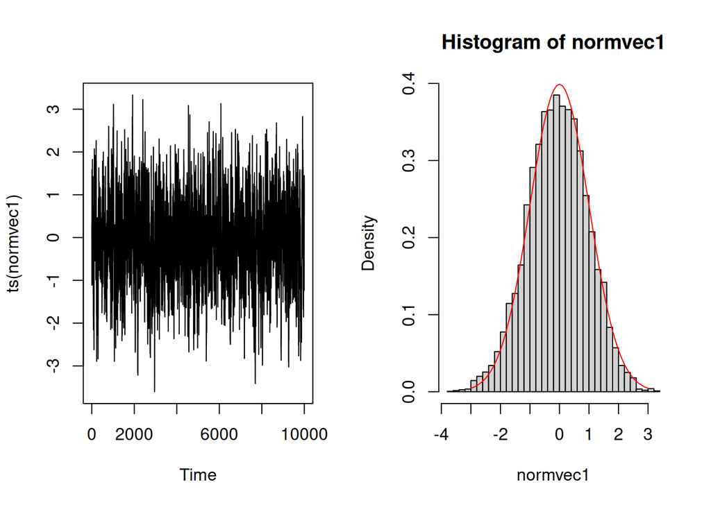

```r
k = 10000 # Number of iterations of the MC

normvec<-norm(k,1)
normvec1 = normvec[1:k]
rate1 = normvec[(k+1)]

par(mfrow=c(1,2))
plot(ts(normvec1))
hist(normvec1,30, prob=T)
val=seq(-3,3,0.1)
points(val,dnorm(val),type='l',col='red')
```

Usually we get rid of the first burnin iterations, where the chain hasn’t reached stationarity yet

The Ergodic Theorem says we can use all iteration from any initial point $x$. However, we are averaging some function of some finite number of samples, so that out average will be a better approximation if we start at a typical point in the density we are sampling from and if this density is closer to the target distribution. We fix burnin=1,000

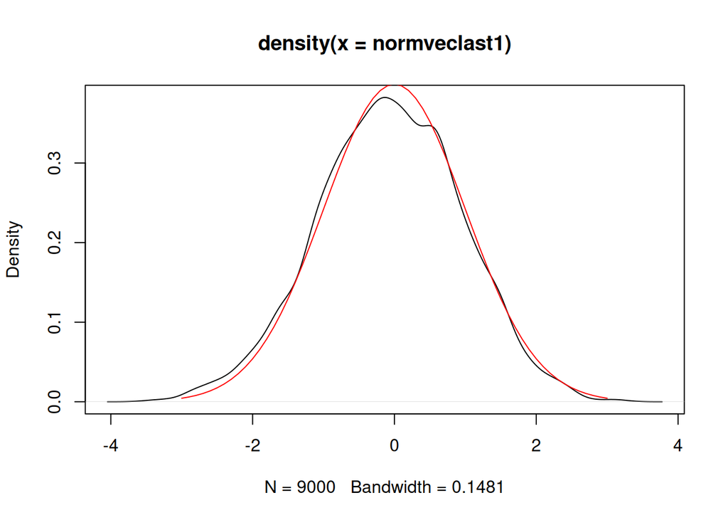

```r
burnin=1000

b1=burnin+1
normveclast1=normvec[b1:k]

par(mfrow=c(1,1))
plot(density(normveclast1))
points(val,dnorm(val),type='l',col='red')
```

```r
rate1
```

```
## [1] 0.7998
```

> $\alpha=10$

Number of iterations of the MC is $k=10,000$

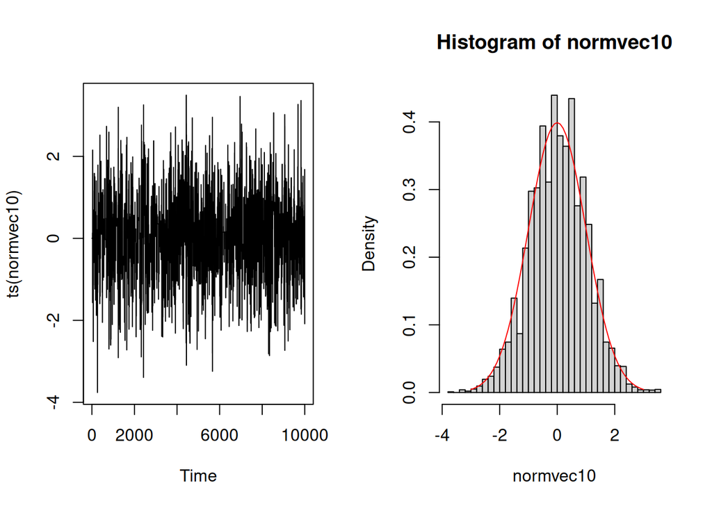

```r
normvec<-norm(k,10)
normvec10 = normvec[1:k]
rate10 = normvec[(k+1)]

par(mfrow=c(1,2))
plot(ts(normvec10))
hist(normvec10,30,prob=T)
points(val,dnorm(val),type='l',col='red')
```

```r
rate10
```

```
## [1] 0.1562
```

> $\alpha=100$

Number of iterations of the MC is $k=10,000$

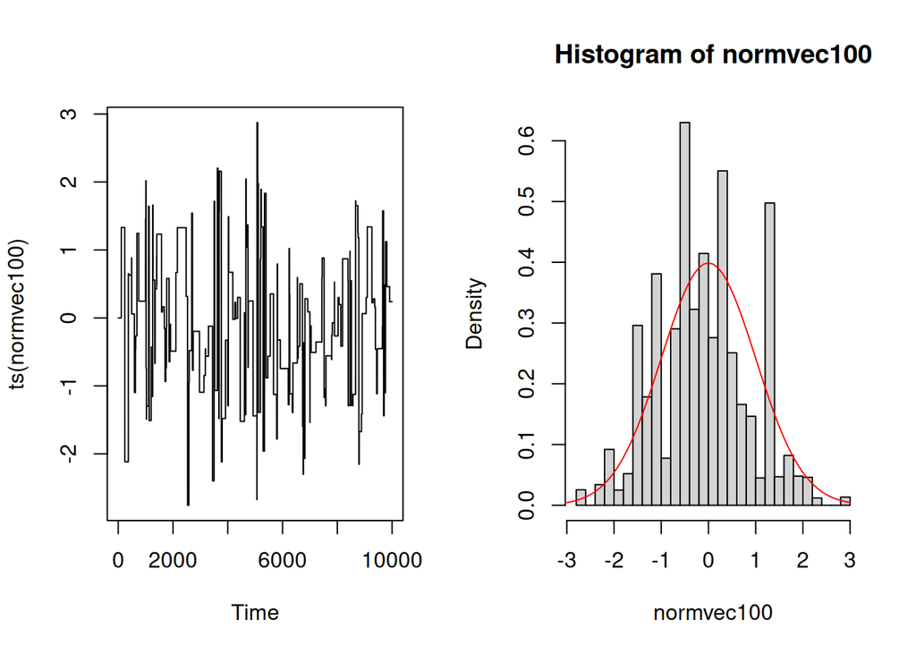

```r
normvec<-norm(k,100)
normvec100 = normvec[1:k]
rate100 = normvec[(k+1)]
par(mfrow=c(1,2))
plot(ts(normvec100))
hist(normvec100,30,prob=T)
points(val,dnorm(val),type='l',col='red')
```

```r
rate100
```

```
## [1] 0.0167
```

COMPARISON among kernel density plots of the simulated MCs for different values of $\alpha$

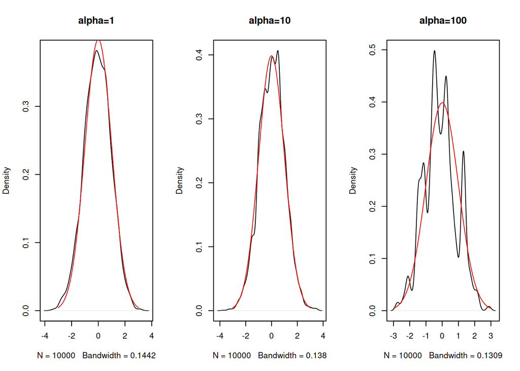

```r
par(mfrow=c(1,3))
plot(density(normvec1),main="alpha=1")
points(val,dnorm(val),type='l',col='red')
plot(density(normvec10),main="alpha=10")
points(val,dnorm(val),type='l',col='red')
plot(density(normvec100),main="alpha=100")
points(val,dnorm(val),type='l',col='red')
```

COMPARISON among traceplots of the simulated MCs for different values of $\alpha$

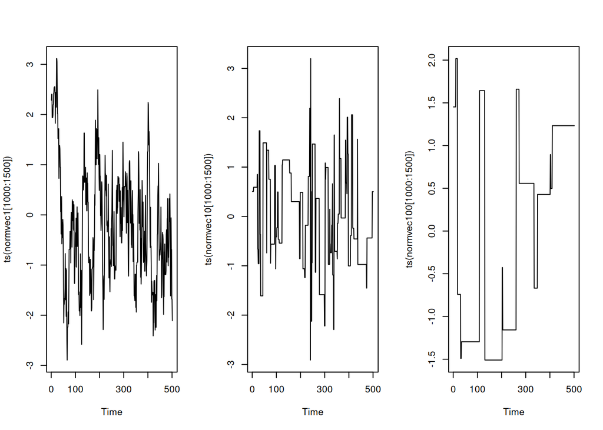

```r
par(mfrow=c(1,3))
plot(ts(normvec1[1000:1500]))
plot(ts(normvec10[1000:1500]))
plot(ts(normvec100[1000:1500]))
```

COMPARISON among acceptance rates of the simulated MCs for different values of $\alpha$

```r
rate1;rate10;rate100
```

```
## [1] 0.7998
```

```
## [1] 0.1562
```

```
## [1] 0.0167
```

### **EXAMPLE 2 - Ex in 6.7 in Albert (2009)**

Data are heights (in inches) of male students from a local college

The interest is in making inference about the mean and sd of the heights; $Y_i \sim {\mathcal N}(\mu,\sigma^2)$ iid

1 inch= 2.54 cm

However data are grouped: out of $n=211$ men, $n_1=14$ of them have height less than 66, $n_2=30$ have height between 66 and 68, ect.

Heights:$<66$, $[66, 68)$, $[68, 70)$, $[70, 72)$, $[70, 72)$, $[72, 74)$, $\geq 74$

Frequency: $n_1=14$, $n_2=30$, $n_3=49$, $n_4=70$, $n_5=33$, $n_6=15$

d is a list defining the intervals and the frequencies

```r
rm(list=ls())
library(LearnBayes)

d=list(int.lo=c(-Inf,seq(66,74,by=2)),int.hi=c(seq(66,74,by=2), Inf),f=c(14,30,49,70,33,15))
d
```

```
## $int.lo
## [1] -Inf   66   68   70   72   74
##
## $int.hi
## [1]  66  68  70  72  74 Inf
##
## $f
## [1] 14 30 49 70 33 15
```

help(groupeddatapost)

it computes the log posterior density of $(\mu,\log \sigma)$ for this model, i.e., for normal sampling where the data is observed in grouped form

> We assume an **IMPROPER prior** for $(\mu,\log(\sigma))$, but only because Jim Albert does: $\pi(\mu,\lambda:=\log(\sigma)) \propto const$ for any $\mu,\lambda$ both in $\mathbb R$ - NEVER assume an improper prior with real data

> **Likelihood** $L(\mu,\sigma;n_1,\ldots,n_6)$: multinomial, with the parameters $(p_1,\ldots,p_6)$, and $p_i$ is the mass assigned by ${\mathcal N}(\mu,\sigma^2)$ to the $i$-th class

> **posterior**: $\pi(\mu,\lambda|n_1,\ldots,n_6)\propto L(\mu,e^{\lambda};n_1,\ldots,n_6)$

help(groupeddatapost)

INPUT: $\theta$=values of $\mu$ and $\log(\sigma)$ where we compute the log-posterior data= dataframe dei dati in forma raggruppata

OUTPUT: log-posterior density

help(laplace)

It is an iterative method (Newton’s method) to compute, for a general posterior density, an estimate of the posterior mode and the associated variance-covariance matrix

INPUT: the log-posterior density, the initial point of the iterative method parameters of the log-posterior density (the vector d in this case)

```r
start=c(70,1) #starting point

fit=laplace(groupeddatapost,start,d)

fit
```

```
## $mode
## [1] 70.169880  0.973644
##
## $var
##              [,1]         [,2]
## [1,] 3.534713e-02 3.520776e-05
## [2,] 3.520776e-05 3.146470e-03
##
## $int
## [1] -350.6305
##
## $converge
## [1] TRUE
```

fit$var is the matrix $(\tilde I_n)^{-1}$, where $\tilde I_n$ is the “generalized observed Fisher information matrix”  
(-d^2/ d d log(pi(mu,log(sigma)|x)) #d is here the DERIVATIVE

```r
diag(fit$var)
```

```
## [1] 0.03534713 0.00314647
```

```r
modal.sds=sqrt(diag(fit$var))
```

Approximately the marginal posterior density of mu is N(70.17,0.035) and the marginal posterior density of lambda=log(sigma) is N(0.974, 0.003)

#### METROPOLIS-HASTINGS ALGORITHM

Build the MC according to a RANDOM WALK Metropolis algorithm: the bivariate proposal density $q$ is $\mathcal N$(val_prec,$c^2 V$) where the scale factor $c=2$, $V$ is the covariance matrix $(\tilde I_n)^{-1}$; this is the covariance of the Gaussian approximation

**The PROPOSAL distribution has to be close to the true posterior, i.e. it should be an approximation of the posterior!!!**

**The scale factor** $c$ determines the behaviour of the MC

> $c=2$

```r
proposal=list(var=fit$var,scale=2) #c=2, 0.1, 10
proposal
```

```
## $var
##              [,1]         [,2]
## [1,] 3.534713e-02 3.520776e-05
## [2,] 3.520776e-05 3.146470e-03
##
## $scale
## [1] 2
```

Proposal distributions: * ${\mathcal N}_2(0,\Sigma)$, * Uniform on the ball of radius R, * t-Student (or more general mixtures of normals)

usually, variance matrix of the Gaussian proposal is $c^2 \cdot$ inverse of the “generalized observed Fisher information” matrix for c >0;

here $c =1/2, 1, 2$ work “well”

The function/command of LearnBayes package is rwmetrop

It simulates iterates of a random walk Metropolis chain for an arbitrary real-valued posterior density defined by the user

help(rwmetrop)

print(rwmetrop)

INPUT: log-posterior = groupeddatapost proposal = N(0,c^2*V) start= initial point of the MC number of iterations=10000 d=parametri della log-posterior = Hyperparameters + data

the acceptance probability $\alpha(x,y)$ is the ratio of the posterior densities (random walk MH)

```r
fit2=rwmetrop(groupeddatapost,proposal,start,10000,d)
```

OUTPUT :

par = a matrix of simulated values where each row corresponds to a simulated value of the vector parameter

accept= the acceptance rate of the algorithm

```r
#fit2
fit2$accept
```

```
## [1] 0.2968
```

> Is the acceptance rate good?

The proposal should be more “diffuse” than posterior density in order to explore the whole support of the posterior density.

If $c$ is too small, the acceptance rate will be high; basically, a small scale $c$ means that I’m sampling the candidate point $y$ from a density with small variance, so that $y$ will be close to $x$, and therefore $\alpha(x,y)=\frac{\pi(y)}{\pi(x)}$ will assume values close to 1.

This means that the MC explores the state space weakly, i.e. the MC moves slowly through the state space, and the algorithm can turn out to be inefficient.

On the other hand, if $c$ is too large, $\alpha(x,y)$ will often be small, and many candidate points will be rejected, so that the overall acceptance rate $r$ will be too small, and also in this case the algorithm is inefficient.

A “good” acceptance rate for RW-MH shold be in $[0.2, 0.5)$ for dimension =1,2,3

For a random walk MH, remember that $\alpha(x,y)=\frac{\pi(y)}{\pi(x)}$ indicates how probable the new proposed sample $y$ is with respect to the current sample $x$.

If we attempt to move to a point that is more probable than the existing point (i.e. a point in a higher-density region of $\pi$), we will always accept the move. However, if we attempt to move to a less probable point, we will sometimes reject the move, and the more the relative drop in probability, the more likely we are to reject the new point.

For **independence chain Metropolis**, rates of acceptance that lead to efficient algorithms have to be higher; theoretically, the higher the ratio of acceptance, the better the convergence rate of this chain.

Let’s go back to posterior inference:

Posterior means and standard deviations (i.e. ergodic means) of $\mu$ and $\log(\sigma)$:

```r
post.means=apply(fit2$par,2,mean)
post.sds=apply(fit2$par,2,sd)
post.means
```

```
## [1] 70.1732707  0.9817342
```

```r
post.sds
```

```
## [1] 0.18594843 0.05742441
```

Comparison between ergodic means and standard deviations and those from the Gaussian approximation of the posterior

```r
cbind(c(fit$mode),modal.sds)
```

```
##                 modal.sds
## [1,] 70.169880 0.18800834
## [2,]  0.973644 0.05609341
```

```r
cbind(post.means,post.sds)
```

```
##      post.means   post.sds
## [1,] 70.1732707 0.18594843
## [2,]  0.9817342 0.05742441
```

In this case the approximation is very good

Draw a countour plot of the true posterior (which is known beyond the normalizing constant) with the MC points (from 5001-th on)

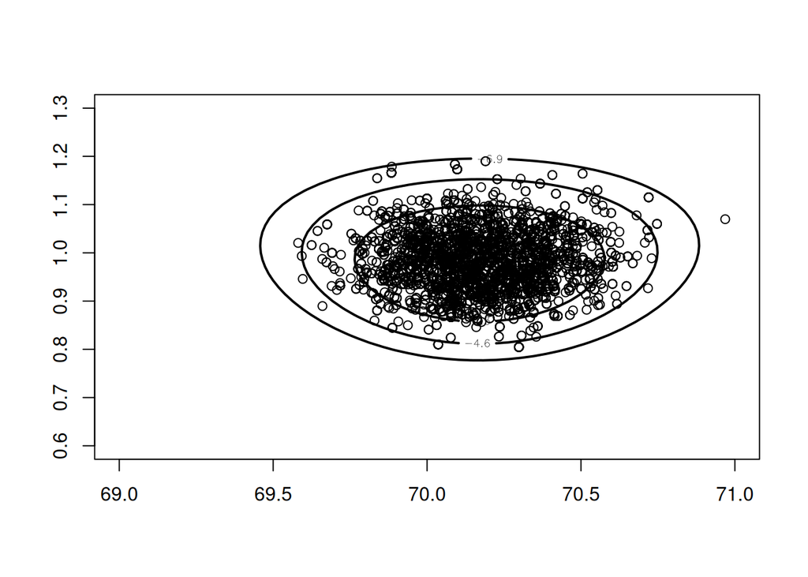

```r
mycontour(groupeddatapost,c(69,71,.6,1.3),d)
points(fit2$par[5001:10000,1],fit2$par[5001:10000,2])
```

Marginal traceplots

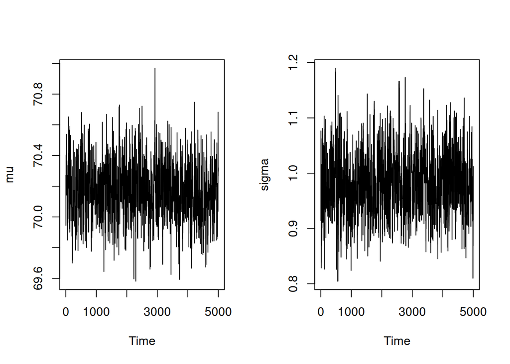

```r
par(mfrow=c(1,2))
plot(ts(fit2$par[5001:10000,1]),ylab="mu")
plot(ts(fit2$par[5001:10000,2]),ylab="sigma")
```

> $c=0.1$

```r
proposal=list(var=fit$var,scale=0.1)
proposal
```

```
## $var
##              [,1]         [,2]
## [1,] 3.534713e-02 3.520776e-05
## [2,] 3.520776e-05 3.146470e-03
##
## $scale
## [1] 0.1
```

```r
fit2=rwmetrop(groupeddatapost,proposal,start,10000,d)
fit2$accept
```

```
## [1] 0.9475
```

```r
post.means=apply(fit2$par,2,mean)
post.sds=apply(fit2$par,2,sd)
post.means
```

```
## [1] 70.1807946  0.9788676
```

```r
post.sds
```

```
## [1] 0.16993520 0.06640847
```

```r
cbind(c(fit$mode),modal.sds)
```

```
##                 modal.sds
## [1,] 70.169880 0.18800834
## [2,]  0.973644 0.05609341
```

```r
cbind(post.means,post.sds)
```

```
##      post.means   post.sds
## [1,] 70.1807946 0.16993520
## [2,]  0.9788676 0.06640847
```

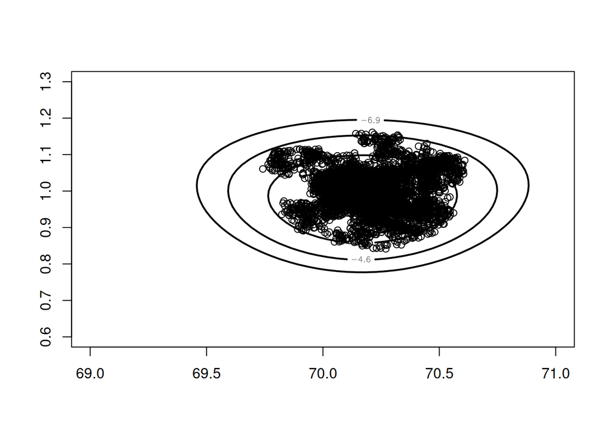

```r
mycontour(groupeddatapost,c(69,71,.6,1.3),d)
points(fit2$par[5001:10000,1],fit2$par[5001:10000,2])
```

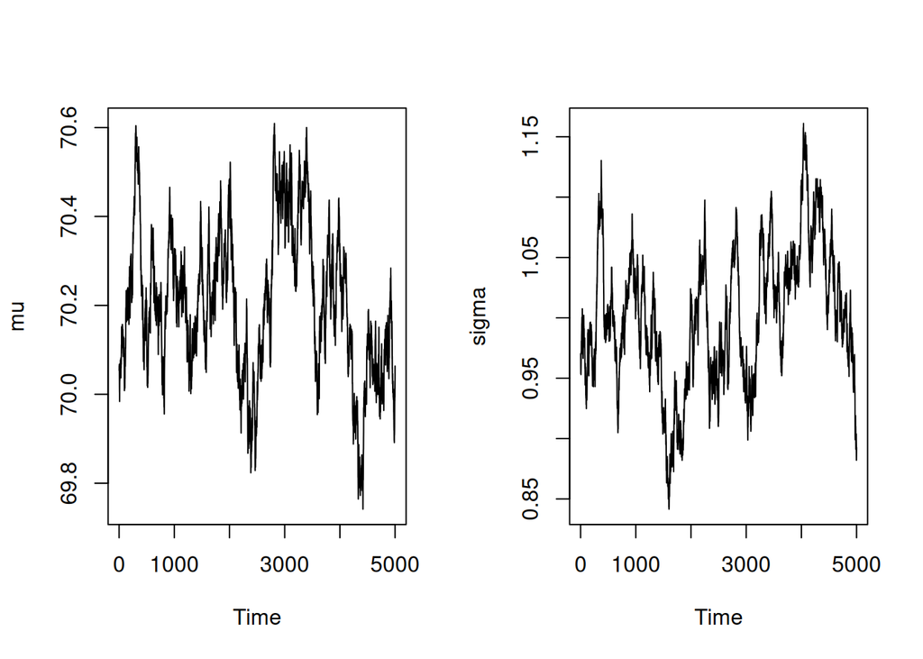

```r
par(mfrow=c(1,2))
plot(ts(fit2$par[5001:10000,1]),ylab="mu")
plot(ts(fit2$par[5001:10000,2]),ylab="sigma")
```

> $c=10$

```r
proposal=list(var=fit$var,scale=10)
proposal
```

```
## $var
##              [,1]         [,2]
## [1,] 3.534713e-02 3.520776e-05
## [2,] 3.520776e-05 3.146470e-03
##
## $scale
## [1] 10
```

```r
fit2=rwmetrop(groupeddatapost,proposal,start,10000,d)
fit2$accept
```

```
## [1] 0.0176
```

```r
post.means=apply(fit2$par,2,mean)
post.sds=apply(fit2$par,2,sd)
post.means
```

```
## [1] 70.1710526  0.9722898
```

```r
post.sds
```

```
## [1] 0.17299486 0.05042968
```

```r
cbind(c(fit$mode),modal.sds)
```

```
##                 modal.sds
## [1,] 70.169880 0.18800834
## [2,]  0.973644 0.05609341
```

```r
cbind(post.means,post.sds)
```

```
##      post.means   post.sds
## [1,] 70.1710526 0.17299486
## [2,]  0.9722898 0.05042968
```

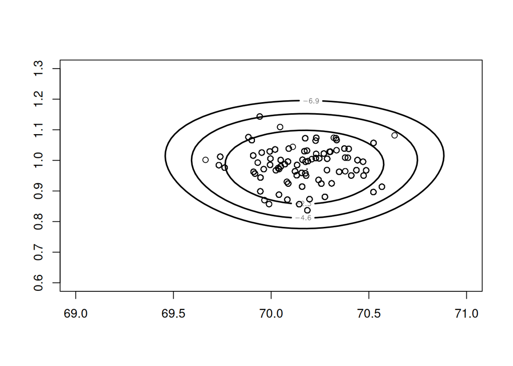

```r
mycontour(groupeddatapost,c(69,71,.6,1.3),d)
points(fit2$par[5001:10000,1],fit2$par[5001:10000,2])
```

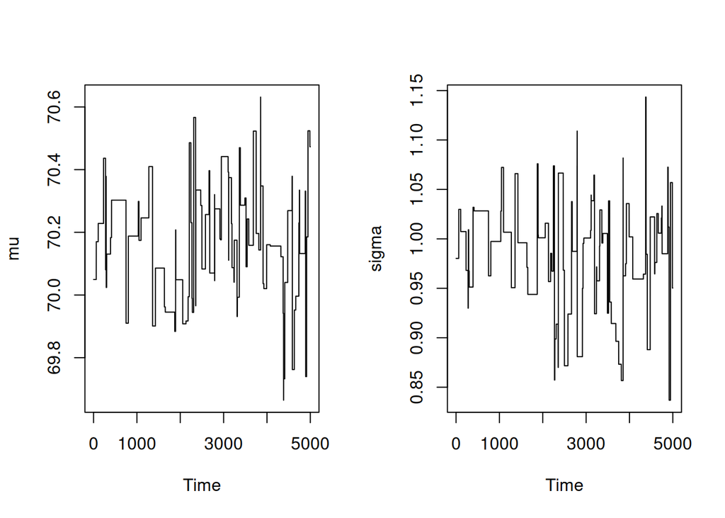

```r
par(mfrow=c(1,2))
plot(ts(fit2$par[5001:10000,1]),ylab="mu")
plot(ts(fit2$par[5001:10000,2]),ylab="sigma")
```